# OHIBC: Clean Waters goal prep

# 2 Methods

## 2.1 Calculate nutrient scores

Nutrient scores are determined using the 3 nm offshore region. Scores are calculated as (1 - mean nutrient pressure); since nutrient pressure scales from 0 to 1, a region with mean pressures near zero will result in a region score near 1.

```r
rgn_extract <- function(rast, rgn_poly) {
  message('Extracting raster ', names(rast))
  ptm <- proc.time()
  rgn_vals <- raster::extract(rast, rgn_poly, weights = FALSE)
  message('... elapsed time: ', round((proc.time() - ptm)[3], 2), ' sec')

  names(rgn_vals) <- rgn_poly@data$rgn_id

  ### For the dataframe without cell weights, each list is just a
  ### vector of values, so we can simply assign that to a column in
  ### the data frame.
  rgn_vals_df <- data.frame()
  for (rgn_id in names(rgn_vals)) {
    temp_df <- data.frame(rgn_id   = as.numeric(rgn_id),
                          cell_val = unlist(rgn_vals[[rgn_id]]))
    rgn_vals_df <- rbind(rgn_vals_df, temp_df)
  }

  return(rgn_vals_df)
}
```

```r
### nutrient: rescaled fertilizers from 2002-2013

### 1. load regions
if(!exists('bc_rgn_poly')) bc_rgn_poly <- readOGR(dsn = path.expand(dir_spatial),
                                                  layer = 'ohibc_rgn')
if(!exists('bc_3nm_poly')) bc_3nm_poly <- readOGR(dsn = path.expand(dir_spatial),
                                                  layer = 'ohibc_offshore_3nm')
```

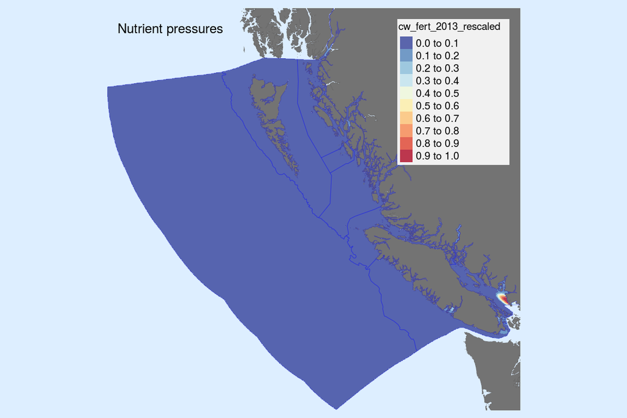

```r
### 2. load layers
nutr_layer_files <- list.files(file.path(dir_goal_anx, 'rescaled_layers'),
                               pattern = 'fert',
                               full.names = TRUE)
nutr_stack <- stack(nutr_layer_files, not_tracked = TRUE) %>%
  setNames(nutr_layer_files %>% basename %>% str_replace('.tif', '')) %>%
  raster::crop(bc_rgn_poly)

years <- names(nutr_stack) %>%
  str_extract('[0-9]{4}') %>%
  as.integer()

rgns_list <- list('po_nutrient'     = bc_rgn_poly,
                  'po_nutrient_3nm' = bc_3nm_poly)

reload <- FALSE

for (i in seq_along(rgns_list)) { # i <- 1
  po_filename <- file.path(dir_goal, 'output', paste0(names(rgns_list)[i], '.csv'))
  if(file.exists(po_filename) & reload == FALSE) {
    message('Pressure file exists: \n  ', po_filename)
    git_prov(po_filename, filetype = 'output')
    next()
  }

  message('Calculating nutrient pressures from ', names(rgns_list)[i])
  nutr_list <- vector('list', length = length(years))
  for (j in 1:length(years)) {
    # j <- 1
    message('In loop; processing layer ', j, ' out of ', length(years))
    tmp_df <- rgn_extract(nutr_stack[[j]], rgns_list[[i]])
    nutr_list[[j]] <- tmp_df %>%
      rename(nutr_val = cell_val) %>%
      mutate(year = years[j])
  }

  nutr_df <- bind_rows(nutr_list)

  po_nutr <- nutr_df %>%
    group_by(year, rgn_id) %>%
    summarize(nutr_pressure = mean(nutr_val, na.rm = TRUE))

  write_csv(po_nutr, po_filename)

}

nutr_map <- plot_rast_map(nutr_stack[[nlayers(nutr_stack)]],
                          rgn_poly = bc_rgn_poly,
                          rev_scale = TRUE,
                          title = 'Nutrient pressures')
```

## 2.2 Calculate chemical scores

Chemical scores are determined using the 3 nm offshore region. Since these rasters are sums of multiple rescaled chemical pollution source layers, values can exceed 1.0. So the cell values must be clipped to 1.0 (simple clip, not a new normalization)

```r
### chemical: sum of rescaled inorganic (no TS) + ocean (no TS) + pesticides (2002-2013)

### 1. load regions
bc_rgn_poly <- readOGR(dsn = path.expand(dir_spatial),
                       layer = 'ohibc_rgn')
bc_3nm_poly <- readOGR(dsn = path.expand(dir_spatial),
                       layer = 'ohibc_offshore_3nm')
```

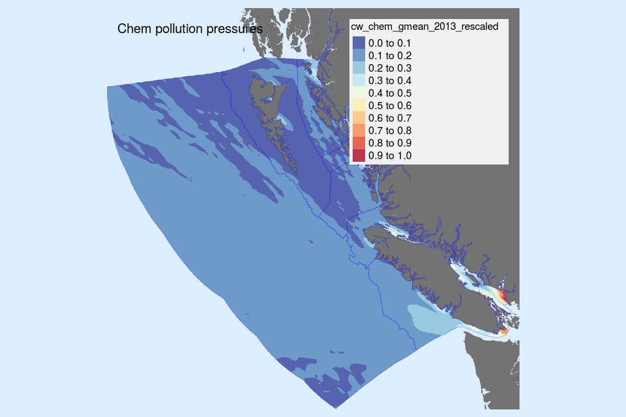

```r
### 2. load layer(s)
chem_layer_files <- list.files(file.path(dir_goal_anx, 'rescaled_layers'),
                               pattern = 'chem_gmean',
                               full.names = TRUE)
chem_stack <- stack(chem_layer_files, not_tracked = TRUE) %>%
  setNames(chem_layer_files %>%
             basename %>%
             str_replace('\\.tif', '')) %>%
  raster::crop(bc_rgn_poly)

### NOTE:  The chem layers are sums of multiple sources of chemical pollution.
### These sums exceed 1.0; anything over 1 must be rescaled.
chem_stack_clipped <- chem_stack
values(chem_stack_clipped)[values(chem_stack_clipped) > 1] <- 1

years <- names(chem_stack_clipped) %>%
  str_extract('[0-9]{4}') %>%
  as.integer()

rgns_list <- list('po_chemical'     = bc_rgn_poly,
                  'po_chemical_3nm' = bc_3nm_poly)

reload <- FALSE

for (i in seq_along(rgns_list)) { # i <- 1

  po_filename <- file.path(dir_goal, 'output', paste0(names(rgns_list)[i], '.csv'))

  if(file.exists(po_filename) & reload == FALSE) {
    message('Pressure file exists: \n  ', po_filename)
    git_prov(po_filename, filetype = 'output')
    next()
  }

  message('Calculating chemical pressures from ', names(rgns_list)[i])
  chem_list <- vector('list', length = length(years))
  for (j in 1:length(years)) {
    # j <- 1
    message('In loop; processing layer ', j, ' out of ', length(years))
    tmp_df <- rgn_extract(chem_stack_clipped[[j]], rgns_list[[i]])
    chem_list[[j]] <- tmp_df %>%
      rename(chem_val = cell_val) %>%
      mutate(year = years[j])
  }

  chem_df <- bind_rows(chem_list)

  po_chem <- chem_df %>%
    group_by(year, rgn_id) %>%
    summarize(chem_pressure = mean(chem_val, na.rm = TRUE))

  write_csv(po_chem, po_filename)

}

chem_map <- plot_rast_map(chem_stack[[nlayers(chem_stack)]],
                          rgn_poly = bc_rgn_poly,
                          rev_scale = TRUE,
                          title = 'Chem pollution pressures')
```

## 2.3 Calculate trash scores

Trash scores are calculated across the entire EEZ. There is no time series for this layer.

```r
### trash: rescaled marine plastics (no TS)

### 1. load regions
bc_rgn_poly <- readOGR(dsn = path.expand(dir_spatial),
                       layer = 'ohibc_rgn')
bc_3nm_poly <- readOGR(dsn = path.expand(dir_spatial),
                       layer = 'ohibc_offshore_3nm')
```

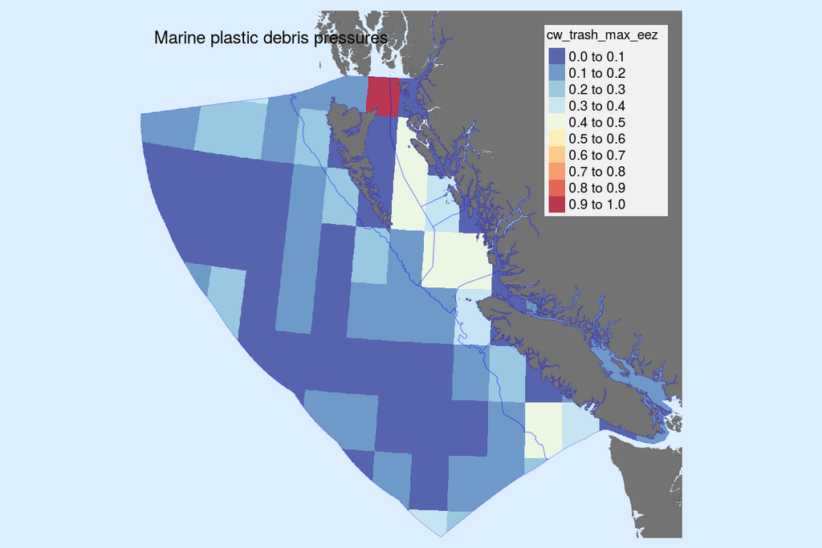

```r
### 2. load layer(s)
trash_layer_files <- list.files(file.path(dir_goal, 'rescaled_layers'),
                               pattern = 'trash',
                               full.names = TRUE)

if(length(trash_layer_files) > 1) {
  message('More than one trash rescaled layer file! \n  ', paste(trash_layer_files, collapse = '\n  '))

  ### select max, linear scale, EEZ ref point
  quantile_tag <- str_detect(trash_layer_files, '_max_')
  region_tag   <- str_detect(trash_layer_files, '_eez')

  trash_layer_file <- trash_layer_files[quantile_tag & region_tag]
  message('Using: \n  ', trash_layer_file)
} else {
  trash_layer_file <- trash_layer_files[1]
}


trash_rast <- raster(trash_layer_file) %>%
  setNames(trash_layer_file %>%
             basename %>%
             str_replace('.tif', '')) %>%
  raster::crop(bc_rgn_poly)


rgns_list <- list('po_trash'     = bc_rgn_poly)
                  # 'po_trash_3nm' = bc_3nm_poly)

for (i in seq_along(rgns_list)) { # i <- 1

  message('Calculating marine debris pressures from ', names(rgns_list)[i])
  trash_df <- rgn_extract(trash_rast, rgns_list[[i]]) %>%
    rename(trash_val = cell_val)

  po_trash_df <- trash_df %>%
    group_by(rgn_id) %>%
    summarize(trash_pressure = mean(trash_val, na.rm = TRUE))

  write_csv(po_trash_df, file.path(dir_goal, 'output', paste0(names(rgns_list)[i], '.csv')))
}

trash_map <- plot_rast_map(trash_rast,
                          rgn_poly = bc_rgn_poly,
                          rev_scale = TRUE,
                          title = 'Marine plastic debris pressures')
```

### 2.3.1 Calculate pathogens scores

All calcs done in the `cw_pathogens.Rmd` script.

|  | rgn_id | year | path_pressure |
| --- | --- | --- | --- |
| 1 | 1 | 2001 | 0.00549375954297278 |
| 2 | 1 | 2002 | 0.00531718503697272 |
| 3 | 1 | 2003 | 0.00514061053097267 |
| 4 | 1 | 2004 | 0.00496403602497261 |
| 5 | 1 | 2005 | 0.00478746151897255 |
| 6 | 1 | 2006 | 0.00461088701297249 |
| 7 | 1 | 2007 | 0.00469315384462383 |
| 8 | 1 | 2008 | 0.00477542067627518 |
| 9 | 1 | 2009 | 0.00485768750792652 |
| 10 | 1 | 2010 | 0.00493995433957786 |

[output cut: 86 more lines]

## 2.4 Calculate geometric mean of all scores.

```r
nutr_score_df  <- read_csv(file.path(dir_goal, 'output', 'po_nutrient_3nm.csv'))
chem_score_df  <- read_csv(file.path(dir_goal, 'output', 'po_chemical_3nm.csv'))
trash_score_df <- read_csv(file.path(dir_goal, 'output', 'po_trash.csv')) %>%
  group_by(rgn_id) %>%
  mutate(year = NA) %>%
  complete(year = unique(nutr_score_df$year), nesting(trash_pressure)) %>%
  ungroup()
path_score_df <- read_csv(file.path(dir_goal, 'output', 'po_pathogen.csv'))

cw_score_df <- nutr_score_df %>%
  full_join(chem_score_df,  by = c('year', 'rgn_id')) %>%
  full_join(path_score_df,  by = c('year', 'rgn_id')) %>%
  full_join(trash_score_df, by = c('year', 'rgn_id')) %>%
  gather(type, value, nutr_pressure:trash_pressure) %>%
  filter(!is.na(value)) %>%
  mutate(component_score = 1 - value)

write_csv(cw_score_df, file.path(dir_goal, 'int/cw_component_scores.csv'))

cw_score_summary <- cw_score_df %>%
  group_by(rgn_id, year) %>%
  summarize(n_sources = n(),
            prod = prod(component_score),
            score = prod^(1/n_sources), ### this finishes our geometric mean
            sources = paste(type, collapse = ', ') %>% str_replace_all('_pressure', ''),
            values  = paste(round(value, 4), collapse = ', ')) %>%
  ungroup()

write_csv(cw_score_summary, file.path(dir_goal, 'int', 'cw_score_summary.csv'))

DT::datatable(cw_score_summary %>%
                mutate(prod = round(prod, 4),
                       score = round(score, 4))
              )
```

|  | rgn_id | year | n_sources | prod | score | sources | values |
| --- | --- | --- | --- | --- | --- | --- | --- |
| 1 | 1 | 2001 | 1 | 0.9945 | 0.9945 | path | 0.0055 |
| 2 | 1 | 2002 | 4 | 0.583 | 0.8738 | nutr, chem, path, trash | 0.0102, 0.1255, 0.0053, 0.3228 |
| 3 | 1 | 2003 | 4 | 0.5833 | 0.8739 | nutr, chem, path, trash | 0.0098, 0.1255, 0.0051, 0.3228 |
| 4 | 1 | 2004 | 4 | 0.583 | 0.8738 | nutr, chem, path, trash | 0.0104, 0.1256, 0.005, 0.3228 |
| 5 | 1 | 2005 | 4 | 0.582 | 0.8734 | nutr, chem, path, trash | 0.0124, 0.1256, 0.0048, 0.3228 |
| 6 | 1 | 2006 | 4 | 0.5838 | 0.8741 | nutr, chem, path, trash | 0.0095, 0.1256, 0.0046, 0.3228 |
| 7 | 1 | 2007 | 4 | 0.5791 | 0.8724 | nutr, chem, path, trash | 0.0171, 0.1257, 0.0047, 0.3228 |
| 8 | 1 | 2008 | 4 | 0.5835 | 0.874 | nutr, chem, path, trash | 0.0098, 0.1255, 0.0048, 0.3228 |
| 9 | 1 | 2009 | 4 | 0.5837 | 0.8741 | nutr, chem, path, trash | 0.0094, 0.1255, 0.0049, 0.3228 |
| 10 | 1 | 2010 | 4 | 0.577 | 0.8716 | nutr, chem, path, trash | 0.0202, 0.126, 0.0049, 0.3228 |

[output cut: 110 more lines]

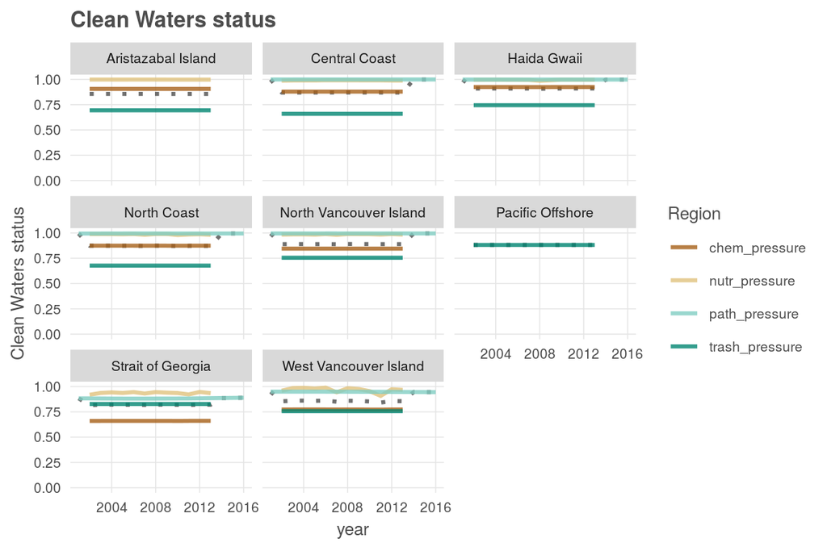

```r
cw_score_df      <- read_csv(file.path(dir_goal, 'int/cw_component_scores.csv'))
cw_score_summary <- read_csv(file.path(dir_goal, 'int', 'cw_score_summary.csv'))

cw_status_components <- cw_score_summary %>%
  select(rgn_id, year, score) %>%
  mutate(type = 'total') %>%
  bind_rows(cw_score_df %>% rename(score = component_score) %>% select(-value)) %>%
  left_join(get_rgn_names(), by = c('rgn_id'))


cw_status_plot <- ggplot(cw_status_components %>% filter(type != 'total'),
                           aes(x = year, y = score)) +
  ggtheme_plot() +
  geom_line(data = cw_status_components %>%
              filter(type == 'total'),
            aes(group = type),
            color = 'grey30', alpha = .8, size = 1, linetype = 'dotted') +
  geom_line(aes(color = type, group = type), size = 1, alpha = .8) +
  scale_colour_brewer(palette = 'BrBG') +
  ylim(0, 1) +
  labs(x = 'year',
       y = 'Clean Waters status',
       title = 'Clean Waters status',
       color = 'Region') +
  facet_wrap( ~ rgn_name)

print(cw_status_plot)
```

```r
prov_wrapup()
```

# 3 Provenance

- *Run ID: 6 (f42872d); run tag: “standard run”*
- *Run elapsed time: 172.797 seconds; run memory usage: 45650.1 MB*
- *System info:*
  - *System: Linux, Release: 4.4.0-133-generic. Machine: x86_64. User: ohara.*
  - *R version: R version 3.4.4 (2018-03-15), Platform: x86_64-pc-linux-gnu, Running under: Ubuntu 14.04.5 LTS.*
  - *Attached base packages: stats, graphics, grDevices, utils, datasets, methods, base*
  - *Other attached packages: bindrcpp_0.2.2, tmap_2.0, provRmd_0.1.1, RColorBrewer_1.1-2, forcats_0.3.0, stringr_1.3.1, dplyr_0.7.6, purrr_0.2.5, readr_1.1.1, tidyr_0.8.1, tibble_1.4.2, ggplot2_3.0.0, tidyverse_1.2.1, raster_2.6-7, rgdal_1.3-3, sp_1.3-1*

[figure not shown]

| sequence | file_name | parent_chunk | file_dir | filetype | uncomm_chgs | commit_hash_short |
| --- | --- | --- | --- | --- | --- | --- |
| 0 | cw_goal_est.rmd | prov_footer | ~/github/ohibc/prep/cw/v2017 | parent_script | False | 0dd97d4 |
| 0 | cw_goal_est.rmd#calc_chem_scores | calc_chem_scores | ~/github/ohibc/prep/cw/v2017 | parent_chunk | False | 0dd97d4 |
| 0 | cw_goal_est.rmd#calc_geom_means | calc_geom_means | ~/github/ohibc/prep/cw/v2017 | parent_chunk | False | 0dd97d4 |
| 0 | cw_goal_est.rmd#calc_nutrient_scores | calc_nutrient_scores | ~/github/ohibc/prep/cw/v2017 | parent_chunk | False | 0dd97d4 |
| 0 | cw_goal_est.rmd#calc_trash_scores | calc_trash_scores | ~/github/ohibc/prep/cw/v2017 | parent_chunk | False | 0dd97d4 |
| 0 | cw_goal_est.rmd#plot_them | plot_them | ~/github/ohibc/prep/cw/v2017 | parent_chunk | False | 0dd97d4 |
| 0 | cw_goal_est.rmd#prov_footer | prov_footer | ~/github/ohibc/prep/cw/v2017 | parent_chunk | False | 0dd97d4 |
| 0 | cw_goal_est.rmd#setup | setup | ~/github/ohibc/prep/cw/v2017 | parent_chunk | False | 0dd97d4 |
| 1 | rast_tools.R | setup | ~/github/ohibc/src/R | sourced_script | False | 7148267 |
| 2 | ohibc_rgn.shp | calc_nutrient_scores | ~/github/ohibc/prep/_spatial | input | False | 4d7d2bc |

[output cut: 44 more lines]